# Assignment 7

Giang Vu

4/15/2021

## Homework 7

### 1.

Even though only the first 3 columns of x are relevant in calculating y, looking at the correlation coefficients, we cannot see this.

```r
n <- 100
p <- 10
s <- 3
set.seed(0)
x <- matrix(rnorm(n*p), n, p)
b <- c(-0.7, 0.7, 1, rep(0, p-s))
y <- x %*% b + rt(n, df=2)

cor(x,y)
```

```
##                [,1]
##  [1,] -0.2526434175
##  [2,]  0.1239284685
##  [3,]  0.1673840288
##  [4,] -0.2522804417
##  [5,] -0.0371161818
##  [6,]  0.1561141420
##  [7,] -0.1175268150
##  [8,] -0.0899681839
##  [9,] -0.0002104895
## [10,]  0.0506851086
```

### 2.

The two densities are plotted below, with the red line from normal distribution, and blue line for t-distribution.

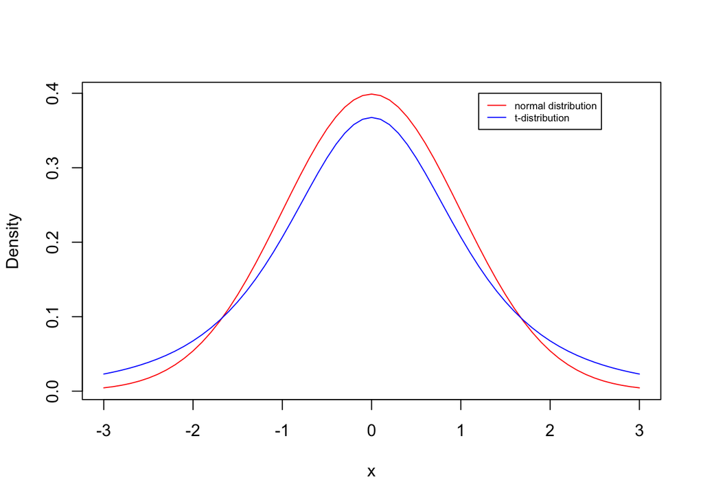

```r
plot(seq(-3,3,0.1),dnorm(seq(-3,3,0.1),mean = 0,sd=1),type = "l",col = "red", xlab = "x", ylab = "Density")
lines(seq(-3,3,0.1),dt(seq(-3,3,0.1),3),col="blue")
legend(1.2,0.4,legend=c("normal distribution","t-distribution"), lty = 1, col = c("red","blue"),cex=0.6)
```

### 3.

The function huber.loss() is defined below.

```r
psi <- function(r, c = 1) {
1
return(ifelse(r^2 > c^2, 2*c*abs(r) - c^2, r^2))
}

huber.loss <- function(beta){
  return(sum(aaply(y - x %*% beta,1,psi)))
}

huber.loss(b) #test with original b
```

```
## [1] 228.543
```

### 4.

It took 127 iterations to converge, and the final coefficient estimates is printed below.

```r
#grad.descent from lecture
grad.descent <- function(f, x0, max.iter = 200, step.size = 0.05, stopping.deriv = 0.01, ...) {

  n    <- length(x0)
  xmat <- matrix(0, nrow = n, ncol = max.iter)
  xmat[,1] <- x0

  for (k in 2:max.iter) {
    # Calculate the gradient
    grad.cur <- grad(f, xmat[ ,k-1], ...)

    # Should we stop?
    if (all(abs(grad.cur) < stopping.deriv)) {
      k <- k-1; break
    }

    # Move in the opposite direction of the grad
    xmat[ ,k] <- xmat[ ,k-1] - step.size * grad.cur
  }

  xmat <- xmat[ ,1:k] # Trim
  return(list(x = xmat[,k], xmat = xmat, k = k))
}

#run grad descent to get estimate of beta in gd
gd <- grad.descent(huber.loss, x0 = rep(0,p), max.iter = 200,
                   step.size = 0.001, stopping.deriv = 0.1)

#final coeff estimates
gd$x
```

```
##  [1] -0.87346579  0.61828938  0.87989797 -0.04910821  0.07277491  0.10229815
##  [7] -0.12513246 -0.14559243 -0.11903666 -0.02250130
```

### 5.

Looking at the plot below of Huber loss values against iteration number, we can see that gradient descent made the objective function decrease at each iteration.  
In the early iterations, the objective function was decreased at a faster rate, while towards the end, the decline slowed down.

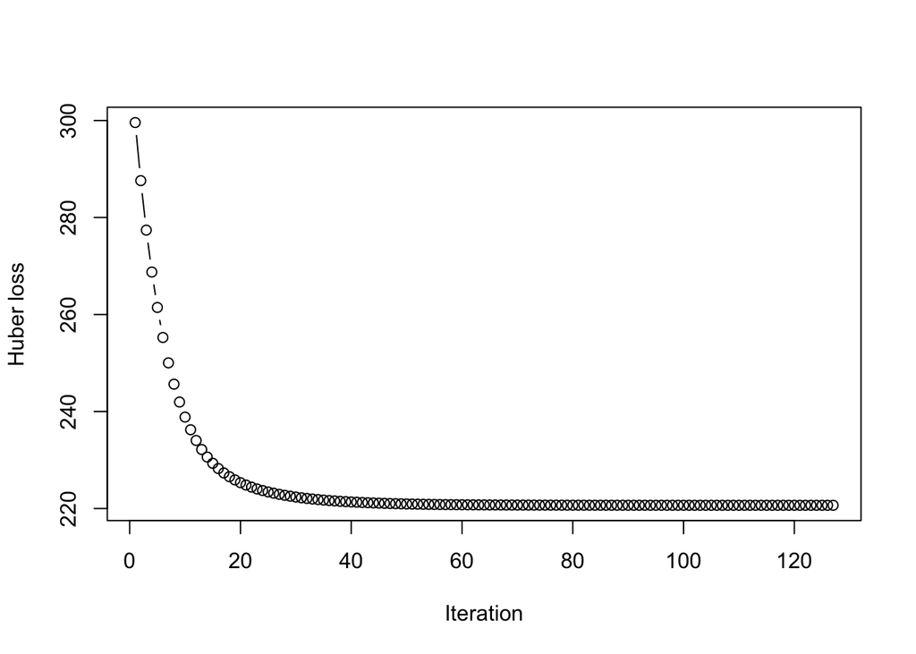

```r
#obj vector
obj <- aaply(gd$xmat,2,huber.loss)

#plot
plot(x=names(obj),y=obj,type = "b",
     xlab = "Iteration", ylab = "Huber loss")
```

### 6.

With a larger step size, the criterion isn’t decreasing at each iteration anymore, and gradient descent didn’t converge at the end.  
Looking at (a part of) the xmat matrix of the gradient descent result, we can see that the signs for the coefficient estimates for the first 3 variables (almost) always alternate after one iteration, which resulted in the plot that we had here with a fluctuating Huber loss values across iterations.

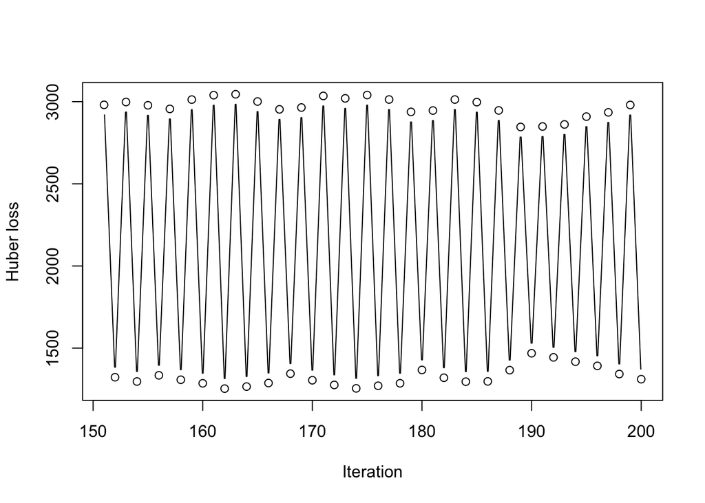

```r
gd2 <- grad.descent(huber.loss, x0 = rep(0,p), max.iter = 200,
                   step.size = 0.1, stopping.deriv = 0.1)

#obj vector
obj2 <- aaply(gd2$xmat,2,huber.loss)

#plot
plot(x=names(obj2[151:200]),y=obj2[151:200],type = "b",
     xlab = "Iteration", ylab = "Huber loss")
```

```r
#xmat
gd2$xmat[,190:200]
```

```
##             [,1]       [,2]       [,3]      [,4]       [,5]      [,6]
##  [1,]  1.2335183 -2.8106467  1.2531152 -3.388921  1.2217578 -3.256382
##  [2,] -0.8678459  1.4023468 -0.4652944  1.577406 -0.9673267  1.167824
##  [3,]  2.7696902 -4.6090522  3.2398951 -4.676549  3.1613969 -4.913893
##  [4,] -1.5142910 -0.7917573 -1.9746018 -1.025082 -1.7068426 -1.371603
##  [5,]  1.8185916 -5.1170213  2.6804162 -5.387366  3.1290220 -6.041194
##  [6,]  1.1713918  1.4218071  1.0696843  1.932369  0.9622015  1.415342
##  [7,] -1.2967216  1.8143466 -0.7383352  1.265605 -0.9877154  1.563563
##  [8,] -1.7243254  3.6984362 -1.4856444  4.174569 -0.8991684  4.298682
##  [9,]  1.4719973 -3.7683198  0.9029692 -2.986782  1.1279742 -3.705448
## [10,]  5.6824964 -9.8197066  5.2481925 -9.667697  4.8922718 -9.333648
##             [,7]      [,8]       [,9]     [,10]      [,11]
##  [1,]  1.1618275 -3.393472  0.9807131 -3.180724  1.0740298
##  [2,] -1.0650953  1.051825 -1.1742513  1.547109 -0.7971898
##  [3,]  3.1594683 -5.295200  2.7237669 -4.846467  2.8860325
##  [4,] -1.7781546 -1.363011 -1.8096897 -1.215318 -1.8822687
##  [5,]  2.6118212 -5.304268  2.5174576 -5.545517  2.1897562
##  [6,]  0.8018572  2.010460  0.9681258  1.269171  0.8721260
##  [7,] -0.6752258  1.382238 -1.1741025  1.662745 -1.0055026
##  [8,] -0.5512029  4.466684 -1.1367493  4.435315 -1.5049278
##  [9,]  0.6126740 -3.453085  1.1539810 -3.803485  0.9241456
## [10,]  5.3365238 -9.710445  4.8759715 -9.997831  4.7508245
```